# 6 Analysis of longitudinal data

### 6.1. Data Wrangling and loading the data sets

The Data wrangling part with exploring the data can be found [here](https://github.com/kreikka/IODS-project/blob/master/data/meet_and_repeat.R). This weeks data sets ‘RATS’ and ‘BPRS’ are longitudinal, including variables with multiple observations in different time points (=multivariate). Clinical trials, especially human health intervention studies are something I’m familiar with, so I was happy with this weeks theme, although I did not have as much time to dive in to the exercises as I would have wanted to.

```r
# Access the libraries needed for the Assignment 6:
library(readr)
library(dplyr)
library(tidyr)
library(ggplot2)
```

```r
# load the data sets created in the Data wrangling (long form data):
BPRSL <- read_csv(file="C:\\Users\\kuud\\Work Folders\\IODS\\IODS-project\\data\\bprsl.csv")
RATSL <- read_csv(file="C:\\Users\\kuud\\Work Folders\\IODS\\IODS-project\\data\\ratsl.csv")
```

### 6.2. Part 1: The RATS data

First I’ll look at the repeated weight measurement data of rats.

When taking a ‘glimpse()’ of the data, I can see that the **ID** and **Group** need to be turned into factors again.

```r
# Take a glimpse at the RATSL data
glimpse(RATSL)
```

```
## Rows: 176
## Columns: 5
## $ ID     <dbl> 1, 2, 3, 4, 5, 6, 7, 8, 9, 10, 11, 12, 13, 14, 15, 16, 1, 2, 3,…
## $ Group  <dbl> 1, 1, 1, 1, 1, 1, 1, 1, 2, 2, 2, 2, 3, 3, 3, 3, 1, 1, 1, 1, 1, …
## $ WD     <chr> "WD1", "WD1", "WD1", "WD1", "WD1", "WD1", "WD1", "WD1", "WD1", …
## $ Weight <dbl> 240, 225, 245, 260, 255, 260, 275, 245, 410, 405, 445, 555, 470…
## $ Time   <dbl> 1, 1, 1, 1, 1, 1, 1, 1, 1, 1, 1, 1, 1, 1, 1, 1, 8, 8, 8, 8, 8, …
```

```r
# Factor variables ID and Group
RATSL$ID <- factor(RATSL$ID)
RATSL$Group <- factor(RATSL$Group)

# Take a glimpse at the RATSL data
glimpse(RATSL)
```

```
## Rows: 176
## Columns: 5
## $ ID     <fct> 1, 2, 3, 4, 5, 6, 7, 8, 9, 10, 11, 12, 13, 14, 15, 16, 1, 2, 3,…
## $ Group  <fct> 1, 1, 1, 1, 1, 1, 1, 1, 2, 2, 2, 2, 3, 3, 3, 3, 1, 1, 1, 1, 1, …
## $ WD     <chr> "WD1", "WD1", "WD1", "WD1", "WD1", "WD1", "WD1", "WD1", "WD1", …
## $ Weight <dbl> 240, 225, 245, 260, 255, 260, 275, 245, 410, 405, 445, 555, 470…
## $ Time   <dbl> 1, 1, 1, 1, 1, 1, 1, 1, 1, 1, 1, 1, 1, 1, 1, 1, 8, 8, 8, 8, 8, …
```

Next I’ll plot the repeated weight measures for all rats by the treatment groups.

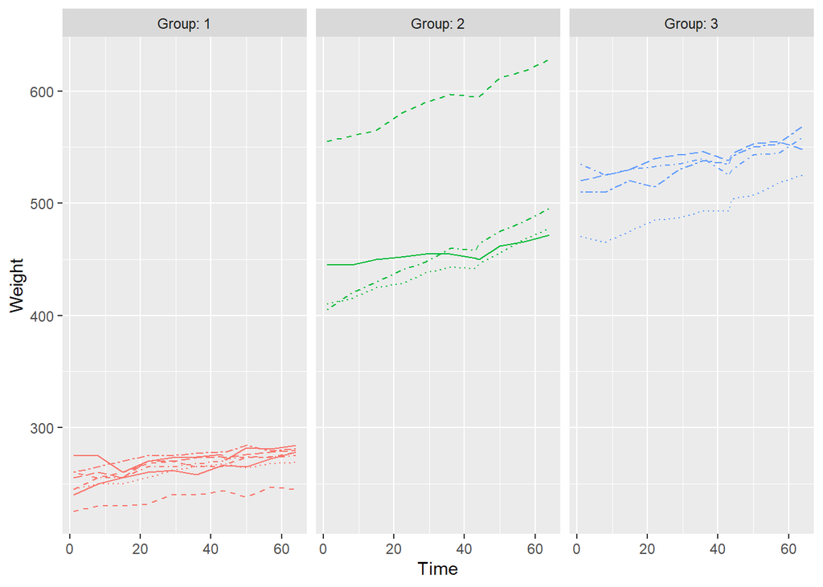

```r
# Draw the plot of weight development of each of the rats by groups
ggplot(RATSL, aes(x = Time, y = Weight, linetype = ID, col = Group)) +
  geom_line() +
  scale_linetype_manual(values = rep(1:10, times=4)) +
  facet_grid(. ~ Group, labeller = label_both) +
  theme(legend.position = "none") +
  scale_y_continuous(limits = c(min(RATSL$Weight), max(RATSL$Weight)))
```

It seems that the weight stays almost the same in the Group 1, whereas both groups 2 and 3 have a trend of weight gain during the study period. The groups have different baseline weights, Group 1 having the lightest rats throughout the study. Group 2 has one rat that is different from the others in the same group. Overall the growth curves appear consistent, general trend being weight gain over time.

The plots above are quite clear, but I’ll still look at the weight development with standardized values too. The plot can be used to see how weight at beginning associates with weight changes during the study. The standardized values are obtained by subtracting the mean weight from the original mean and then dividing by the corresponding visit standard deviation.

$$standardised(x) = \frac{x - mean(x)}{
sd(x)}$$

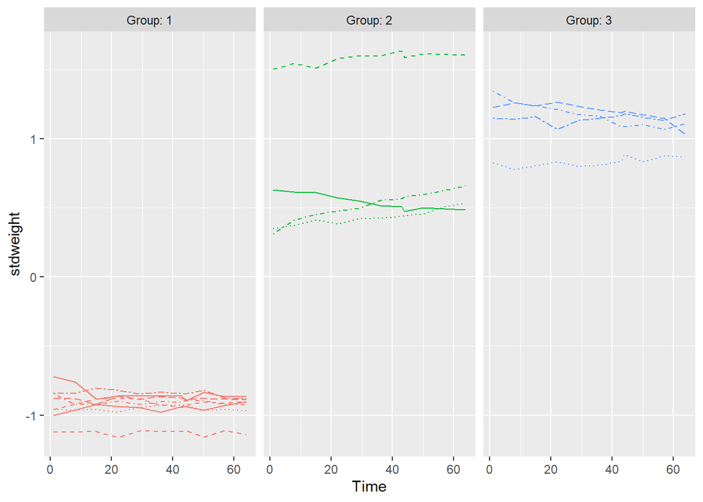

```r
# Standardise the variable Weight
RATSL <- RATSL %>%
  group_by(Time) %>%
  mutate(stdweight = (Weight - mean(Weight))/sd(Weight) ) %>%
  ungroup()

# Draw the plot of weight development of each of the rats by groups
ggplot(RATSL, aes(x = Time, y = stdweight, linetype = ID, col = Group)) +
  geom_line() +
  scale_linetype_manual(values = rep(1:10, times=4)) +
  facet_grid(. ~ Group, labeller = label_both) +
  theme(legend.position = "none") +
  scale_y_continuous(limits = c(min(RATSL$stdweight), max(RATSL$stdweight)))
```

The plots seem similar to the one drawn with non-standardized weight values.

```r
# Document last knitted:
date()
```

```
## [1] "Mon Dec 11 20:55:05 2023"
```